# TP N° 1: Análisis exploratorio de datos

## Ejercicio 34

1. Con los datos `riesgo_arbolado.xlsx` transforme los datos de `DAP` en puntuaciones Z. ¿Que representan esos valores? Haga un histograma.
2. Repita el calculo de Z pero agrupando por especie. ¿Qué representan esos valores? Haga un gráfico de caja por especie y comente los resultados.

**Respuestas**

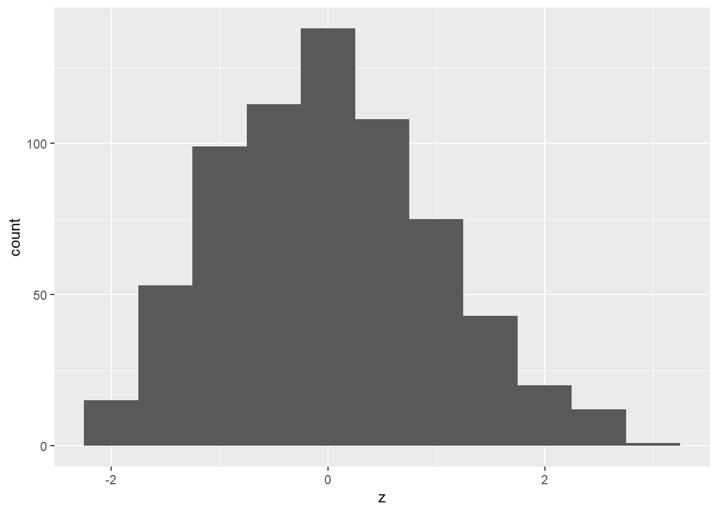

   ```r
   arbolado <- mutate(arbolado, z = (DAP - mean(DAP))/sd(DAP))

   ggplot(arbolado, aes(x = z)) + geom_histogram(binwidth = 0.5)
   ```

   Los valroes `z` representan la posición de los datos respecto de la media general medida en unidades de desvíos estándar.

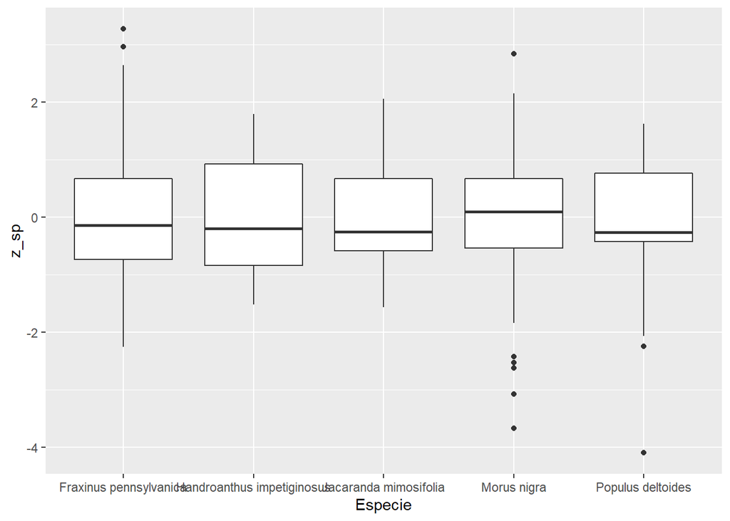

   ```r
   arbolado <- arbolado %>%
     group_by(Especie) %>%
     mutate(z_sp = (DAP - mean(DAP))/sd(DAP))

   ggplot(arbolado, aes(x = Especie, y = z_sp)) + geom_boxplot()
   ```

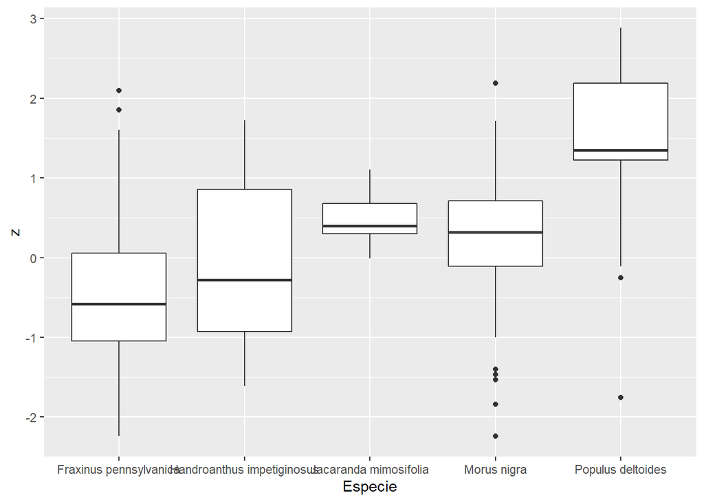

   ```r
   ggplot(arbolado, aes(x = Especie, y = z)) + geom_boxplot()
   ```

   En este caso los valroes `z_sp` representan la posición de cada arbol respecto a la media de su especie. El gráfico de caja de `z` muestra las diferencias entre las especies mientras que el de `z_sp` todas las cajas están centradas cerca de 0.

## Ejercicio 35

Con los datos `riesgo_arbolado.xlsx` averigüe el valor de riesgo min, max y medio de cada especie. Comente los resultados.

**Respuestas**

```r
arbolado %>%
    group_by(Especie) %>%
    summarise(min = min(riesgo), media = mean(riesgo), max = max(riesgo))
```

```
# A tibble: 5 x 4
  Especie                      min media   max
  <chr>                      <dbl> <dbl> <dbl>
1 Fraxinus pennsylvanica         3  5.69    12
2 Handroanthus impetiginosus     3  4.61    10
3 Jacaranda mimosifolia          3  5.83    11
4 Morus nigra                    3  7.68    12
5 Populus deltoides              3  9.5     12
```

En todas las especies hubo arboles sin riesgo (el valor 3 es el mínimo de cada componente). En promedio los arboles *Populus* es tuvieron asociados a mayores valores de riesgo. Salvo *Handroanthus* y *Jacaranda*, el resto tuvo arboles con riesgo máximo.